# PEC2_adonis_gonzalez

[figure not shown]

M2.859 · Visualización de datos aula 2

2020-2 · Máster universitario en Ciencia de datos (Data science)

Estudios de Informática, Multimedia y Telecomunicación

Nombre: Adonis González Godoy

# PEC 2: Creación de visualizaciones de datos

## 1. Título

Evolución de los tratados de paz a lo largo de los años en las diferentes regiones

## 2. Descripción

En este documento se ha utilizado una base de datos "Peaceagreements database (PA-X)" que contiene 1868 acuerdos de paz, se encuentran diferentes procesos de paz entre los años 1990 y mediados de 2020. El dataset esta disponible en la siguiente URL: (https://www.peaceagreements.org/search). Se trata de una base de datos creada y mantenida por la Law School de la Universidad de Edimburgo.

El dataset contienes diferentes conflictos que se han producidos entre estados, gobiernos, sociedad y/o grupos paramilitares a lo largo de los años y que a pesar de todo, muchos de ellos siguen teniendo problemas. En esta resolución de conflictos algunos de los temas que trataban para poner fin eran, los diferentes grupos de personas (niños, personas discapacitadas, ancianos, etc.), diferentes géneros (mujeres, hombres, niños, LGBTI y familia), la gobernanza (como reformar o establecer nuevas instituciones políticas), los derechos humanos y la igualdad, los repartos de poderes, reforma del sector de justicia, tierra, propiedad y medio ambiente, justicia transicional (amnistías o indultos) e implementación.

## 3. Los datos

Cargamos las librerias necesarias

```python
import numpy as np
import pandas as pd
import seaborn as sns
import matplotlib.pyplot as plt
import os
```

Cargamos el conjunto de datos

```python
ROOT_DIR = os.path.abspath("../")
DATA_DIR = os.path.join(ROOT_DIR, "data")
data_file = os.path.join(DATA_DIR, "pax_all_agreements_data.xlsx")
```

```python
data_xlsx = pd.ExcelFile(data_file)
```

El conjunto de datos lo pasaremos a pandas dataframe

```python
sheet_names = data_xlsx.sheet_names
df = data_xlsx.parse(sheet_names[0])
```

Tenemos un primer contacto con el dataset, mostramos las 2 primeras filas

```python
df.head(2)
```

|  | Con | Contp | PP | PPName | Reg | AgtId | Ver | Agt | Dat | Status | ... | TjRep | TjRSym | TjRMa | TjNR | ImUN | ImOth | ImRef | ImPK | ImE | ImSrc |
| --- | --- | --- | --- | --- | --- | --- | --- | --- | --- | --- | --- | --- | --- | --- | --- | --- | --- | --- | --- | --- | --- |
| 0 | Afghanistan | Government/territory | 2 | Afghanistan: 2000s Post-intervention process | Europe and Eurasia | 2232 | 3 | Resolution of Intra Afghan Peace Conference in... | 2019-07-08 | Multiparty signed/agreed | ... | 0 | 0 | 0 | 0 | 0 | 0 | 0 | 0 | 0 | 1 |
| 1 | Afghanistan | Government | 2 | Afghanistan: 2000s Post-intervention process | Europe and Eurasia | 1739 | 2 | Agreement between the Islamic Republic of Afgh... | 2016-09-22 | Multiparty signed/agreed | ... | 0 | 0 | 0 | 0 | 0 | 0 | 0 | 0 | 1 | 1 |

2 rows × 266 columns

```python
df.shape
```

```
(1868, 266)
```

Como se puede ver la dimensión del dataset es de 1868 filas x 266 columnas. Es un dataset extenso y disponible para aplicar diferentes técnicas de análisis.

A continuación se analizará la estructura y resumen de datos, de esta forma se entenderá mejor el dataset.

```python
df.describe()
```

|  | PP | AgtId | Ver | Lgt | N_characters | Loc1GWNO | Loc2GWNO | UcdpAgr | PamAgr | CowWar | ... | TjRep | TjRSym | TjRMa | TjNR | ImUN | ImOth | ImRef | ImPK | ImE | ImSrc |
| --- | --- | --- | --- | --- | --- | --- | --- | --- | --- | --- | --- | --- | --- | --- | --- | --- | --- | --- | --- | --- | --- |
| count | 1868.000000 | 1868.000000 | 1868.000000 | 1868.000000 | 1868.000000 | 1857.000000 | 246.000000 | 2.970000e+02 | 33.000000 | 1115.000000 | ... | 1868.000000 | 1868.000000 | 1868.000000 | 1868.000000 | 1868.000000 | 1868.000000 | 1868.000000 | 1868.000000 | 1868.000000 | 1868.0 |
| mean | 84.870450 | 1155.105996 | 1.249465 | 6.274625 | 11951.505353 | 528.693592 | 439.719512 | 2.903701e+10 | 17.272727 | 759.324664 | ... | 0.177195 | 0.011242 | 0.102248 | 0.300321 | 0.193790 | 0.238758 | 0.009636 | 0.291756 | 0.383833 | 1.0 |
| std | 42.273883 | 663.722169 | 0.590838 | 17.194469 | 37644.455332 | 223.469441 | 195.075032 | 3.602522e+11 | 10.022702 | 254.762977 | ... | 0.553679 | 0.105459 | 0.303056 | 0.608157 | 0.395372 | 0.426439 | 0.097715 | 0.454692 | 0.486448 | 0.0 |
| min | 1.000000 | 1.000000 | 1.000000 | 1.000000 | 329.000000 | 41.000000 | 2.000000 | 2.400000e+01 | 1.000000 | 139.000000 | ... | 0.000000 | 0.000000 | 0.000000 | 0.000000 | 0.000000 | 0.000000 | 0.000000 | 0.000000 | 0.000000 | 1.0 |
| 25% | 55.000000 | 568.750000 | 1.000000 | 1.000000 | 2397.250000 | 365.000000 | 346.250000 | 1.107000e+03 | 9.000000 | 817.000000 | ... | 0.000000 | 0.000000 | 0.000000 | 0.000000 | 0.000000 | 0.000000 | 0.000000 | 0.000000 | 0.000000 | 1.0 |
| 50% | 90.000000 | 1135.500000 | 1.000000 | 2.000000 | 4354.000000 | 531.000000 | 371.000000 | 1.334000e+03 | 17.000000 | 857.000000 | ... | 0.000000 | 0.000000 | 0.000000 | 0.000000 | 0.000000 | 0.000000 | 0.000000 | 0.000000 | 0.000000 | 1.0 |
| 75% | 123.000000 | 1736.250000 | 1.000000 | 5.000000 | 9420.500000 | 678.000000 | 625.000000 | 1.523000e+03 | 26.000000 | 905.000000 | ... | 0.000000 | 0.000000 | 0.000000 | 0.000000 | 0.000000 | 0.000000 | 0.000000 | 1.000000 | 1.000000 | 1.0 |
| max | 160.000000 | 2317.000000 | 4.000000 | 323.000000 | 908459.000000 | 940.000000 | 770.000000 | 5.171991e+12 | 34.000000 | 941.000000 | ... | 3.000000 | 1.000000 | 1.000000 | 3.000000 | 1.000000 | 1.000000 | 1.000000 | 1.000000 | 1.000000 | 1.0 |

8 rows × 250 columns

```python
# print(df.dtypes)
obj = df.dtypes
res = []
for key,value in obj.iteritems():
        print(key," -->",value)
#         res.append([key, value])
# print(res)
```

```
Con  --> object
Contp  --> object
PP  --> int64
PPName  --> object
Reg  --> object
AgtId  --> int64
Ver  --> int64
Agt  --> object
Dat  --> object
Status  --> object
Lgt  --> int64
N_characters  --> int64
Agtp  --> object
Stage  --> object
StageSub  --> object
Part  --> object
ThrdPart  --> object
OthAgr  --> object
Loc1ISO  --> object
Loc2ISO  --> object
Loc1GWNO  --> float64
Loc2GWNO  --> float64
UcdpCon  --> object
UcdpAgr  --> float64
PamAgr  --> float64
CowWar  --> float64
GCh  --> int64
GChRhet  --> int64
GChAntid  --> int64
GChSubs  --> int64
GChOth  --> int64
GDis  --> int64
GDisRhet  --> int64
GDisAntid  --> int64
GDisSubs  --> int64
GDisOth  --> int64
GAge  --> int64
GAgeRhet  --> int64
GAgeAntid  --> int64
GAgeSubs  --> int64
```

[output cut: 211 more lines]

```
TjMech  --> int64
TjPrire  --> int64
TjVet  --> int64
TjVic  --> int64
TjMis  --> int64
TjRep  --> int64
TjRSym  --> int64
TjRMa  --> int64
TjNR  --> int64
ImUN  --> int64
ImOth  --> int64
ImRef  --> int64
ImPK  --> int64
ImE  --> int64
ImSrc  --> int64
```

Como se puede observar la mayoría de datos son de tipo integer, por lo general las columnas con tipo de datos object son de tipo String.

### Descripción de variables

A continuación se describre las variables que se han considerado para esta exploración.

| Campo | Descripción |
| --- | --- |
| Con | - Campo de tipo String que se refiere a Country, son los diferentes países en los que se han realizado acuerdos |
| PPName | - Campo de tipo String que contiene el nombre de los acuerdos realizados |
| Reg | - Campo de tipo String que se refiere a Region, contienes las diferentes regiones donde se han realizado los acuerdos |
| Dat | - Campo de tipo Object que contiene fechas, contiene las fechas que en que se firmaron los acuerdos de paz |
| Status | - Campo de tipo String que contiene la descipción del los diferentes tipos de acuerdos |
| Stage | - Campo de tipo String que contiene información sobre la fase del tipo de acuerdo |

Miraremos si el dataset contiene campos con valores nulos.

```python
print(df.isnull().sum().tolist())
```

```
[0, 0, 0, 0, 0, 0, 0, 0, 0, 0, 0, 0, 0, 0, 25, 16, 892, 892, 35, 1622, 11, 1622, 155, 1571, 1835, 753, 0, 0, 0, 0, 0, 0, 0, 0, 0, 0, 0, 0, 0, 0, 0, 0, 0, 0, 0, 0, 0, 0, 0, 0, 0, 0, 0, 0, 0, 0, 0, 0, 0, 0, 0, 0, 0, 0, 0, 0, 0, 0, 0, 0, 0, 0, 0, 0, 0, 0, 0, 0, 0, 0, 0, 0, 0, 0, 0, 0, 0, 0, 0, 0, 0, 0,…
```

```python
obj = df.isnull().sum()
for key,value in obj.iteritems():
    if value > 0:
        print(key," -->",value)
```

```
StageSub  --> 25
Part  --> 16
ThrdPart  --> 892
OthAgr  --> 892
Loc1ISO  --> 35
Loc2ISO  --> 1622
Loc1GWNO  --> 11
Loc2GWNO  --> 1622
UcdpCon  --> 155
UcdpAgr  --> 1571
PamAgr  --> 1835
CowWar  --> 753
```

```python
print(df.isnull().values.sum())
print(df.isna().values.sum())
```

```
9429
9429
```

Estos son los campos con el número de total de valores nulos, estas variables no han sido seleccionadas por lo que se procede a la exploración de los datos.

## 4. Exploración de los datos

En la exploración de los datos nos centraremos principalmente en la evolución de los acuerdos a lo largo de los años dado las regiones/países, tipos de acuerdos y estado que se encuentran.

Primero de todo miraremos desde un punto de vista general los acuerdos por las diferentes regiones.

```python
df.Reg.value_counts()
```

```
Africa (excl MENA)              584
Europe and Eurasia              411
Asia and Pacific                377
Middle East and North Africa    263
Americas                        195
Cross-regional                   38
Name: Reg, dtype: int64
```

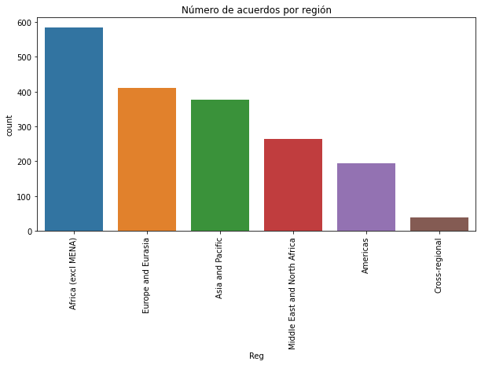

```python
plt.figure(figsize=(10,5))
chart = sns.countplot(x = df.Reg, data = df, order=df.Reg.value_counts().iloc[:len(df.Reg.value_counts())].index)
chart.set_xticklabels(chart.get_xticklabels(), rotation=90)
chart.set_title("Número de acuerdos por región")
```

Como se puede ver la región que más veces aparece con acuerdos es la región de Africa (excl MENA), seguida de Europa y Eurasia.

Miramos las diferentes tipo de acuerdos que se han firmado.

```python
df.Status.value_counts()
```

```
Multiparty signed/agreed            1725
Unilateral document                  125
Status unclear                        10
Agreement with subsequent status       8
Name: Status, dtype: int64
```

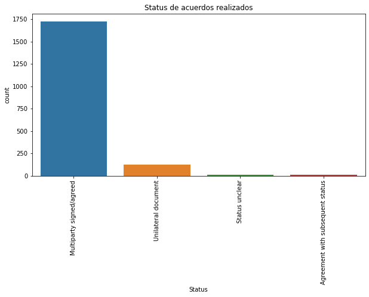

```python
plt.figure(figsize=(10,5))
chart = sns.countplot(x = df.Status, data = df, order=df.Status.value_counts().iloc[:len(df.Status.value_counts())].index)
chart.set_xticklabels(chart.get_xticklabels(), rotation=90)
chart.set_title("Status de acuerdos realizados")
```

Se puede observar que los acuerdo de Multiparty son el tipo de acuerdo acuerdo que más se ha realizado, en total 1725 acuerdos donde ha estado involucrado más de un grupo de protagonistas.

Miramos la fase en la que se encuentra los diferentes tipos de acuerdos.

```python
df.Stage.value_counts()
```

```
Pre        513
SubPar     475
Cea        388
Imp        335
SubComp    113
Ren         43
Oth          1
Name: Stage, dtype: int64
```

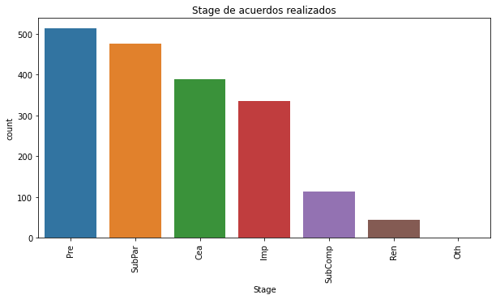

```python
plt.figure(figsize=(10,5))
chart = sns.countplot(x = df.Stage, data = df, order=df.Stage.value_counts().iloc[:len(df.Stage.value_counts())].index)
chart.set_xticklabels(chart.get_xticklabels(), rotation=90)
chart.set_title("Stage de acuerdos realizados")
```

Se puede observar las 7 etapas en las que se pueden encontrar los diferentes acuerdos de paz. Mayorítariamente se observa que los acuerdos se encuentran en la etapa Pre y SubPar.

En el stage Pre, los acuerdos pretenden que las partes lleguen a negociar las incompatibilidades que están en el centro del conflicto y en Subpar son los acuerdos que afectan a las partes que están debatiendo y acordando temas importantes para resolver.

A continuación miramos los diferentes países con más acuerdos, en esta exploración, se ha configurado el gráfico para que se pueda visualizar correctamente estableciendo solo los 10 paises con más acuerdos.

```python
df.Con.value_counts()[:10]
```

```
Bosnia and Herzegovina/Yugoslavia (former)    133
Colombia                                      128
Philippines/Mindanao                          126
Syria                                          93
South Sudan                                    51
Nepal                                          51
Yemen                                          50
Croatia/Yugoslavia (former)                    44
South Sudan/Sudan                              44
Central African Republic                       43
Name: Con, dtype: int64
```

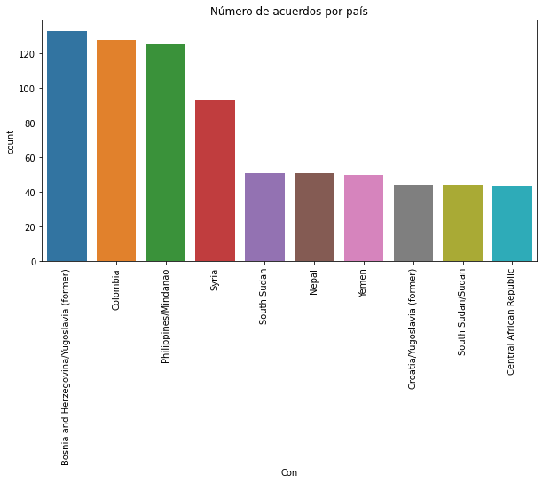

```python
plt.figure(figsize=(10,5))
chart = sns.countplot(x = df.Con, data = df, order=df.Con.value_counts().iloc[:10].index)
chart.set_xticklabels(chart.get_xticklabels(), rotation=90)
chart.set_title("Número de acuerdos por país")
```

Se puede ver que el país con más acuerdos es Bosnia and Herzegovina/Yugoslavia (former) con más de 130 acuerdos seguido de Colombia con 128.

```python
obj = df.Con.value_counts()
print(obj[-10:len(obj)])
```

```
Sudan/Uganda                                                           1
Eritrea/Sudan                                                          1
China/Japan/North Korea/Russia/South Korea/United States of America    1
Afghanistan/Pakistan                                                   1
Costa Rica/El Salvador/Guatemala/Honduras/Nicaragua                    1
Indonesia/Portugal/(East Timor)                                        1
Macedonia/Yugoslavia (former)                                          1
Central African Republic/Chad/Sudan/(Darfur)                           1
Central African Republic/Sudan                                         1
Bangladesh/Chittagong Hill Tracts                                      1
Name: Con, dtype: int64
```

También podemos ver los diferentes países con menos acuerdos.

```python
df['Country'] = df['Con'].apply(str.split, args = '/')
```

```python
df.Country
```

```
0       [Afghanistan]
1       [Afghanistan]
2       [Afghanistan]
3       [Afghanistan]
4       [Afghanistan]
            ...
1863          [Yemen]
1864          [Yemen]
1865       [Zimbabwe]
1866       [Zimbabwe]
1867       [Zimbabwe]
Name: Country, Length: 1868, dtype: object
```

Después de mirar las diferentes regiones y paises, nos centraremos en la evolución a lo largo de los años que se han producido estos acuerdos.

```python
print(df.Dat.min())
print(df.Dat.max())
```

```
1990-02-15
2020-04-09
```

La fecha mínima registrada es en el año 1990 y la última en el 2020.

```python
df.Dat.dtypes
```

```
dtype('O')
```

Primero antes que nada, haremos una transformación de la columna fecha (Dat) que contiene las fechas que se realizaron los acuerdos. Esta columna contiene las fechas en formato Object (O), la pasaremos a formato Date, pero no reemplazaremos, crearemos una nueva columna.

```python
df['Date'] = pd.to_datetime(df.Dat, infer_datetime_format= True)
```

```python
df.Date
```

```
0      2019-07-08
1      2016-09-22
2      2014-09-21
3      2012-07-08
4      2011-12-05
          ...
1863   1994-06-30
1864   1990-04-22
1865   2013-03-19
1866   2008-09-15
1867   2008-07-21
Name: Date, Length: 1868, dtype: datetime64[ns]
```

Como podemos ver ahora sí la tenemos en formato datetime, de esta fecha podemos extraer solo el año y añadiendolo a una nueva columna en el dataframe.

```python
df['Year'] = df['Date'].dt.year
df.Year
```

```
0       2019
1       2016
2       2014
3       2012
4       2011
        ...
1863    1994
1864    1990
1865    2013
1866    2008
1867    2008
Name: Year, Length: 1868, dtype: int64
```

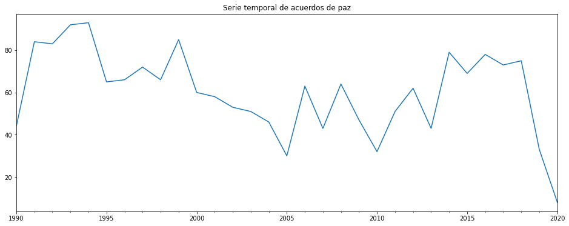

```python
plt.figure(figsize=(16,6))
plt.title("Serie temporal de acuerdos de paz")
fig = df['Date'].value_counts().resample('Y').sum().plot.line()
```

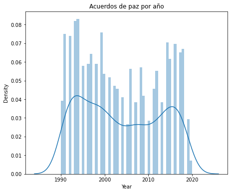

```python
plt.figure(figsize = (16,6))
plt.subplot(121)
sns.distplot(df['Year'], kde = True, bins = 50).set_title('Acuerdos de paz por año')
```

Como observando la serie podemos apreciar que tenemos una ligera tendencia lineal a la baja.

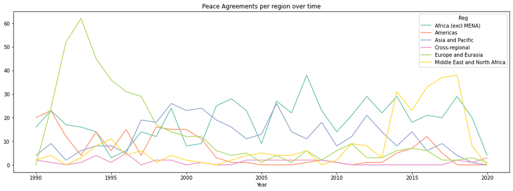

```python
regions_evolution = pd.crosstab(df.Year,df.Reg)
regions_evolution.plot(color=sns.color_palette('Set2',12), title='Peace Agreements per region over time')
fig=plt.gcf()
fig.set_size_inches(18,6)
plt.show()
```

## 5. Procedimiento y herramientas.

En este documento se presenta primer contacto con el dataset. Ha sido realizado usando Jupyter Notebook en un conda enviroment que ejecuta la verisón 3.6 de Python. Las librería que se han usado son las usadas en este documento, entre las principales se tiene que destacar, padas, numpy, matplotlib.

Lo primero que se ha realizado es la carga del dataset para realizar una primera inspección, dimensión, valores nulos, tipo de datos. Cuando se ha requerido se ha transformado para facilitar la manipulación y/o creación de visualizaciones.

La herramienta que se ha utilizado para poder hacer las representaciones gráficas del dashboard es Tableau, esta herramienta permite expresar datos visualmente al transformar acciones de arrastrar y soltar en consultas de dados, en una interfaz intuitiva. Puede permitir incluso aprendizaje automático, estadísticos, lenguaje natural y preparación de los datos inteligentes para que sean más eficaces y permitan aumentar la creatividad de las personas que lo utilizan para hacer análisis.

También se han realizado distintos test con Tableau para poder asegurarse del diseño adecuado que se pretende seleccionar, para que el usuario final puede interactuar. En general, se ha tenido en cuenta que la visualización de todos los gráficos sean capaces de entenderse sin poner texto que los acompañen, pero utilizando herramientas elementales que mejora mucho la legibilidad de las visualizaciones como son las etiquetas y las leyendas.

Por último, el panel de Tableu ha facilitado la realización de las visualizaciones en comparación con matplotlib. Usando esta herramienta resulta más fácil centrarse en lo que se quiere visualizar.

Een este repositorio se encuentra adjunto el dashboard de Tableau.